# Filtering Data

Selecting Rows with `dplyr`

Prof. Dr. Nicolas Meseth

## Overview

- The `filter()` Function
- Comparison Operators
- Combining Conditions (AND & OR)
- Value Ranges & Lists
- Text Filtering
- Dealing with Missing Values (`NA`)
- Advanced Row Selection (`slice`, `distinct`)
- Filtering in Groups

# The `filter()` Function

## The Basic Principle

> `filter()` evaluates conditions and keeps only the rows where the condition is `TRUE`.

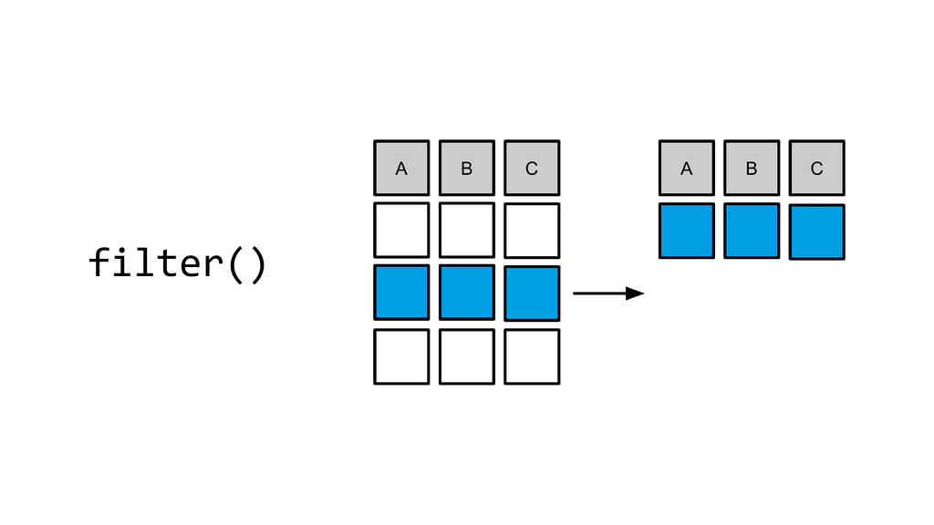

Filtering observations in a Tibble.

## First Example

Keep only original tweets (exclude retweets):

```r
tweets |>
  filter(!is_retweet) |>
  select(screen_name, retweet_count, text)
```

Validate by counting the remaining rows:

```r
tweets |>
  filter(!is_retweet) |>
  nrow()
```

# Comparisons & Combinations

## Comparison Operators

| Operator | Meaning |
| --- | --- |
| `==` | Equal |
| `!=` | Not equal |
| `<` / `<=` | Less than / Less or equal |
| `>` / `>=` | Greater than / Greater or equal |

**Rule of thumb:** `=` is for assignment, `==` is for comparison!

## Logical AND

Multiple conditions separated by comma (`,`) must **all** be true:

```r
tweets |>
  filter(!is_retweet, retweet_count >= 500)
```

Alternatively, you can use `&`:

```r
tweets |>
  filter(!is_retweet & retweet_count >= 500)
```

## Logical OR

Conditions separated by `|` mean **at least one** must be true:

```r
tweets |>
  filter(retweet_count >= 2000 | favorite_count >= 5000)
```

## Watch Your Parentheses!

When mixing `&` and `|`, use parentheses to explicitly control the evaluation order!

```r
tweets |>
  filter(!is_retweet & (retweet_count >= 2000 | favorite_count >= 5000))
```

> Without parentheses, `!is_retweet` would only group with `retweet_count >= 2000`, drastically changing your results!

# Value Ranges & Lists

## The `between()` Helper

Instead of writing two comparisons (`x >= 100 & x <= 500`), use `between()`:

```r
tweets |>
  filter(between(retweet_count, 100, 500))
```

## The Guest List: `%in%`

Filter for multiple precise values using `%in%`:

```r
users <- c("cem_oezdemir", "Karl_Lauterbach")

tweets |>
  filter(screen_name %in% users)
```

Negate it to **exclude** a list of values:

```r
tweets |>
  filter(!screen_name %in% users)
```

# Missing Values & Text

## Dealing with `NA`

`NA` is neither true nor false. It means “missing”. Use `is.na()` to explicitly find missing values:

```r
tweets |>
  filter(is.na(in_reply_to_screen_name))
```

Or keep only rows where the value is present:

```r
tweets |>
  filter(!is.na(in_reply_to_screen_name))
```

## Text Filters

Use `str_detect()` from the `stringr` package to find patterns:

```r
tweets |>
  filter(str_detect(text, "klima"))
```

Ignore case sensitivity:

```r
tweets |>
  filter(str_detect(text, regex("klima", ignore_case = TRUE)))
```

# Multiple Columns

## The `if_any()` Helper

Keep rows if the condition is `TRUE` for **at least one** chosen column:

```r
tweets |>
  filter(if_any(c(retweet_count, favorite_count), \(x) x >= 2000))
```

## The `if_all()` Helper

Keep rows if the condition is `TRUE` for **all** chosen columns:

```r
tweets |>
  filter(if_all(c(retweet_count, favorite_count), \(x) x >= 2000))
```

# Advanced Row Selection

## The `slice()` Family

Select rows by position or rank, rather than logic.

First 3 rows:

```r
tweets |> slice_head(n = 3)
```

Top 5 retweets:

```r
tweets |> slice_max(retweet_count, n = 5)
```

Random sample of 5 rows:

```r
tweets |> slice_sample(n = 5)
```

## Removing Duplicates

Use `distinct()` to keep only unique rows based on specific columns:

```r
tweets |>
  distinct(screen_name)
```

Keep all other columns too, maintaining only the first occurrence:

```r
tweets |>
  distinct(screen_name, .keep_all = TRUE)
```

# Filtering with Groups

## Context-Aware Filters

Together with `group_by()`, filtering evaluates metrics **per group**:

Keep only users with at least 50 tweets in the dataset:

```r
tweets |>
  group_by(screen_name) |>
  filter(n() >= 50) |>
  ungroup()
```

## Top Records per Group

Keep the most retweeted tweet **per user**:

```r
tweets |>
  group_by(screen_name) |>
  slice_max(retweet_count, n = 1) |>
  ungroup()
```

## Summary

- Use **`filter()`** for logical conditions.
- Remember **`==`**, **`!=`**, and combinations (**`&`** / **`,`** / **`|`**).
- Make use of **`between()`** and **`%in%`**.
- Handle missing values with **`is.na()`**.
- Match text with **`str_detect()`**.
- Use **`slice_*()`** for positions / ranks.
- Combine with **`group_by()`** for group-level filtering!